# Tomography

```python
import numpy as np
import scipy
import matplotlib.pyplot as plt
import time
```

## 0) Loading the data

To solve the task, we first need to load the lists of angles and the measured sensor data (and define $M$s so we have all required information to solve the problem).

```python
Nps = [109, 275]
Ms = [77, 195]
alpha_lists = [np.load(f"data/alphas_{M}.npy") for M in Ms]
ys = [np.load(f"data/y_{M}.npy") for M in Ms]

print("Loaded the following datasets:\n")

for i, (Np, M, alphas) in enumerate(zip(Nps, Ms, alpha_lists)):
    print(f"{i}) sensor size {Np}, {len(alphas)} measurements, image size {M}.")
    print(f"  - N = {Np} * {len(alphas)} = {Np * len(alphas)}")
    print(f"  - D = M^2 = {M ** 2}\n")
```

```
Loaded the following datasets:

0) sensor size 109, 90 measurements, image size 77.
  - N = 109 * 90 = 9810
  - D = M^2 = 5929

1) sensor size 275, 179 measurements, image size 195.
  - N = 275 * 179 = 49225
  - D = M^2 = 38025
```

In my opinion, it's better to load the data separately at the beginning (like we do) instead of in the same cell with some calculations whose run-time we want to measure (as in the sample solution) because in theory, that might skew the results. In this case, since it takes ~2ms to load the data, it is negligble.

## 1) Constructing the matrix X

Now we can start constructing the $X$ matrix, as described in the task. We need to use the `scipy.sparse` tools to do so, since the matrix will be large.

```python
def construct_X(M, alphas, Np = None) -> scipy.sparse.coo_matrix:
    if Np is None:
        Np = int(np.ceil(np.sqrt(2) * M))

    N = Np * len(alphas)
    D = M ** 2

    data = []
    i_indexes = []
    j_indexes = []

    # for each angle, calculate the contributions of the rows of the image to the sensor
    c_point = M / 2
    c_sensor = Np / 2

    for i, alpha in enumerate(alphas):
        v_alpha = np.cos(np.deg2rad(alpha)), np.sin(np.deg2rad(alpha))

        for row in range(M):
            offset_row = -(row - c_point) - 0.5
            for column in range(M):
                offset_column = (column - c_point) + 0.5

                # we're projecting a point (vector) onto a vector
                # since we only need the length (index of the sensor), a dot product is sufficient
                idx = np.dot((offset_column, offset_row), v_alpha) + c_sensor - 0.5

                # if the ray is out of bounds, we don't want to include it
                # this is necessary because the larger set has out-of-bounds rays
                s1_valid = 0 <= idx
                s2_valid = idx <= Np

                # distribute among the 2 affected sensors
                s1_pos = int(idx)
                s2_pos = int(idx + 1)

                s1_val = 1 - (idx - s1_pos)
                s2_val = 1 - (s2_pos - idx)

                if s1_valid:
                    data.append(s1_val)
                    i_indexes.append(s1_pos + i * Np)
                    j_indexes.append(column + row * M)

                if s2_valid:
                    data.append(s2_val)
                    i_indexes.append(s2_pos + i * Np)
                    j_indexes.append(column + row * M)

    return scipy.sparse.coo_matrix((data, (i_indexes, j_indexes)), shape=(N, D), dtype=np.float32)
```

Our function works very similarly to the fast version in the sample solution, except it isn't vectorized. As we noted below, the speed (30s) is still decent, but compared to the sample solution (~2s), it's pretty bad.

Now we can check the implementation with the provided `X_example.npy` matrix to see if the construction works:

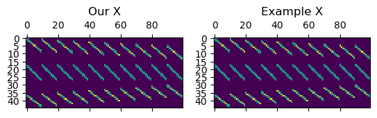

```python
X = construct_X(10, [-33, 1, 42]).toarray()
X_example = np.load(f"data/X_example.npy")

# the matrices should match
assert np.isclose(X, X_example).all()

fig, (ax1, ax2) = plt.subplots(ncols=2)
ax1.matshow(X)
ax1.set_title('Our X')

ax2.matshow(X_example)
ax2.set_title('Example X')
```

It seems that the matrices match so we can calculate the full $X$ matrix for our task.

```python
dataset = 1  # 0 for smaller, 1 for larger

start = time.time()

M = Ms[dataset]
alphas = alpha_lists[dataset]
Np = Nps[dataset]
y = ys[dataset]

X = construct_X(M, alphas, Np)
print(f"Constructed X of size {X.shape} in {time.time() - start:.02f}s")
```

```
Constructed X of size (49225, 38025) in 30.24s
```

Although the matrix construction isn't vectorized, a runtime of 30s for the larger dataset is not terrible.

## 2) Recovering the image

Now that $X$ has been computed, we can use least squares to reconstruct the image. We'll use the sparsity of $X$ to our advantage:

```python
nonzero = X.count_nonzero()
total = np.prod(X.shape)

print(f"X has {nonzero} non-zero values out of {total} total ({nonzero / total * 100:.02f}%)")
```

```
X has 13535943 non-zero values out of 1871780625 total (0.72%)
```

Technically, the sparcity is (100 - 0.72)% = 99.28%, but it's clear what is meant.

Now we can finally run least squares using scipy's `sparse.linalg.lsqr`, obtaining the image:

```python
start = time.time()

# use csc representation, which is much faster for calculating least squares
result = scipy.sparse.linalg.lsqr(X.tocsc(), y)

print(f"Solved sparse least squares in {time.time() - start:.02f}s")
```

```
Solved sparse least squares in 77.66s
```

Our solution takes more than twice as long as the sample solution because we did not change the default tolerances of `lsqr`. With the same tolerances as the sample solution, our code also takes ~30s.

which we can plot:

[figure not shown]

```python
beta = np.reshape(result[0], (M, M))

fig, (ax1) = plt.subplots(ncols=1)
ax1.matshow(beta)
ax1.set_title('Reconstructed image')
```

This result is quite surprising since Homer Simpson's brain seems to be of regular size. We believe that this is the problem and that the brain should be removed for his behavior to return to normal (although the crayon isn't helping the case).

Let's say we went above and beyond in our diagnosis.

## 3) Minimizing the radiation dose

We'll try to minimize the number of projections by eliminating half of the angles at each iteration and see what the reconstructed image looks like.

[figure not shown]

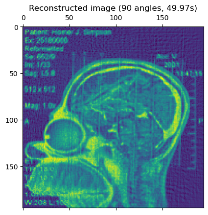

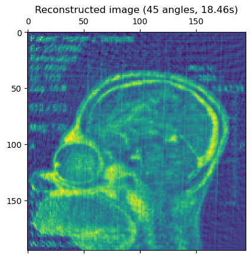

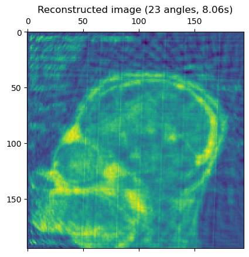

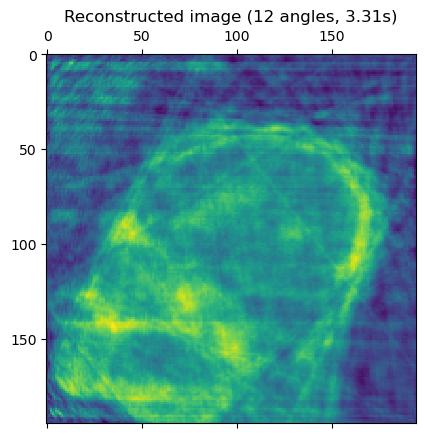

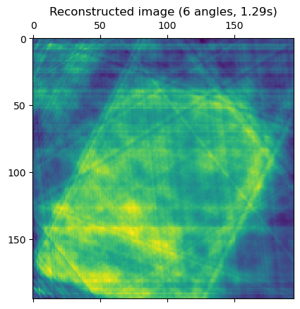

```python
while len(alphas) > 4:
    start = time.time()
    X = construct_X(M, alphas, Np)
    result = scipy.sparse.linalg.lsqr(X.tocsc(), y)
    beta = np.reshape(result[0], (M, M))

    fig, (ax1) = plt.subplots(ncols=1)
    ax1.matshow(beta)
    ax1.set_title(f'Reconstructed image ({len(alphas)} angles, {time.time() - start:.02f}s)')

    alphas = alphas[::2]
    y = y[[i for i in range(y.shape[0]) if i // Np % 2 == 0]]
```

The resolution unsurprisingly deteriorates, but the crayon is still visible at 45 angles (although our opinion might be skewed since we know what to look for). Looking for a specific number of angles might not be productive for this exact reason, but the answer should be at about 45.

We took a slightly different and, in my opinion, cleaner approach to choosing the angles. Our conclusion roughly matches that of the sample solution, although the latter is a bit more elaborate since we did not take tolerance into account.